# Ford GoBike Ride Analysis For the Month of February

## by Godspower Iheanacho

## Investigation Overview

In this project i analysed the fordgobike datasets and explored the information about the rides made by individuals made in the month february 2019.for this analysis , pandas DataFrame were used. The following questions were answered during this project:

- Which of the day of week were most of the trips made.
- the number of user type
- How was the gender distributed.
- Was there any round trip etc.

## Dataset Overview

The datasets consists of information regarding about 183,412 rides made in the month of february.The datasets consists of about 16 features which includes the following:

- duration_sec : duration of trip made in seconds
- start_time : time trip started
- end_time : time trip ended.
- start_station_id: station id where trip started.
- end_station_id : station id where trip ended.
- start_station_latitude : the lattitude location of the station where of the trip started
- end_station_latitude : latitude location of the station where the trip ended.
- end_station_longitude :longitude location of the station where the trip ended.
- start_station_latitude :longitude location of the station where the trip started.
- User_type : type of user(subscriber or customer)
- member_birth_year : Year which member were born
- member_gender : gender of member(male, female and other)
- bike_id : unique identifier of bike used for trips:

### Distribution of trip duration

The trip duration in this datasets has a wide range of values which could result to outliers, from about 1 to 1409. The trip duration is plotted on a logarithmic scale, the distribution takes a normal distribution.

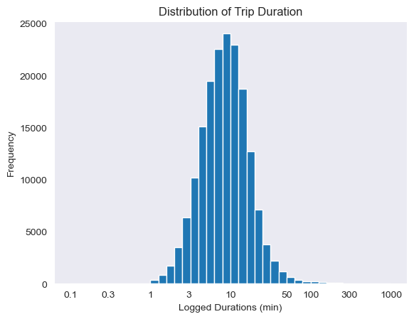

### Which day in the week was most trips made.

The day of the week was plotted on the countplot and we could see that most of the trip were made on the while there was low patronage during the weekend.

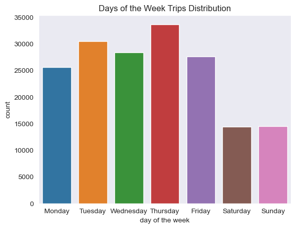

### Trip Distribution by time of the day

From the piechart we could that majority of the trips were made during the day(morning and noon)

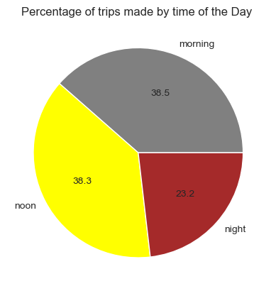

### Number of round trips made

From the countplot we could see that an overwhelming proportions of the trips made were not round trip

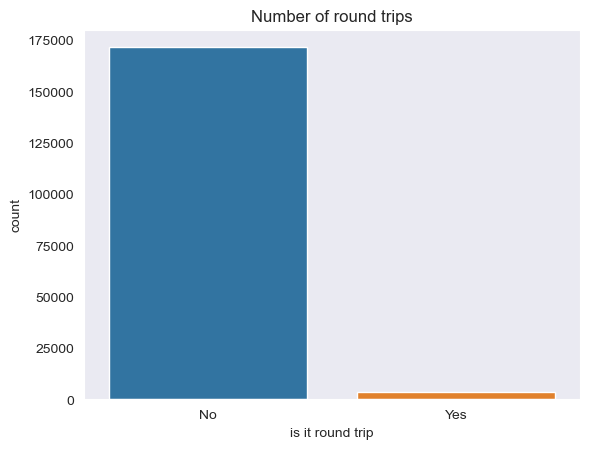

### Distribution of genders that patronise ford Gobike

from the graph the male gender made the highest number of trips than the other genders.

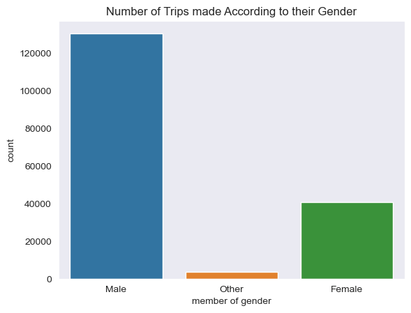

### Number of trips by User type

We can see that majority of those that patronise are mostly subscribers.

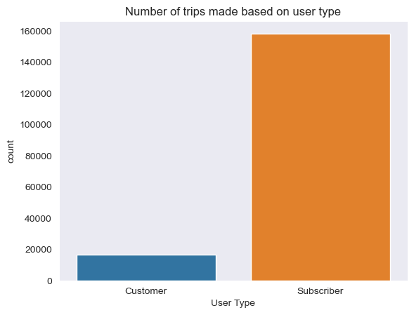

### Average Duration covered by Gender

The barplot shows the other other gender which does not include male and female has the highest average duration. This could bre partly down to the fact that section of gender made the least number of trips.

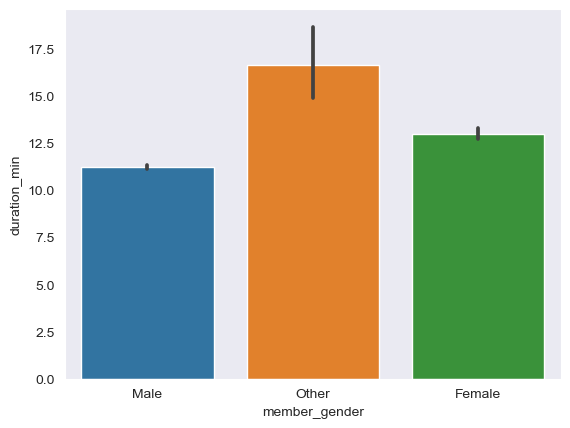

### Number of trips made by hours and Days of the week

from the above heatmap, we could see that most of trips were made between 7am and 9am and rapidly declines from 10am to 16 in the evening. This could be partly down to the fact that most of their have busy schedules during that time of the day. For much of the evening ie between from 17 to 18, activitiees pick-ups as most of their customers returns from work.

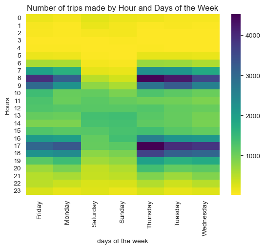